# Data Analysis(Retail Sales)

### Import Library

```python
import pandas as pd
import numpy as np
import matplotlib.pyplot as plt
import seaborn as sns
```

### Import The DataSet

```python
df = pd.read_csv('retail_data.csv')
```

### Show the Data

```python
# show as the all column in data set.
pd.set_option('display.max_rows',None)
pd.set_option('display.max_columns',None)
pd.set_option('display.width',1000)
df.head(1)
```

|  | Transaction_ID | Customer_ID | Name | Email | Phone | Address | City | State | Zipcode | Country | Age | Gender | Income | Customer_Segment | Date | Year | Month | Time | Total_Purchases | Amount | Total_Amount | Product_Category | Product_Brand | Product_Type | Feedback | Shipping_Method | Payment_Method | Order_Status | Ratings | … |
| --- | --- | --- | --- | --- | --- | --- | --- | --- | --- | --- | --- | --- | --- | --- | --- | --- | --- | --- | --- | --- | --- | --- | --- | --- | --- | --- | --- | --- | --- | --- |
| 0 | 8691788 | 37249 | Michelle Harrington | Ebony39@gmail.com | 1414786801 | 3959 Amanda Burgs | Dortmund | Berlin | 77985 | Germany | 21 | Male | Low | Regular | 2023-09-18 | 2023 | September | 0 days 22:03:55 | 3 | 108 | 324 | Clothing | Nike | Shorts | Excellent | Same-Day | Debit Card | Shipped | 5.0 | … |

## Data Cleaning

```python
# how much total rows and column in data set.
df.shape
```

[output not shown]

```python
# info about the all columns.
df.info()
```

```
<class 'pandas.core.frame.DataFrame'>
Index: 293908 entries, 0 to 302009
Data columns (total 30 columns):
 #   Column            Non-Null Count   Dtype
---  ------            --------------   -----
 0   Transaction_ID    293908 non-null  int64
 1   Customer_ID       293908 non-null  int64
 2   Name              293908 non-null  object
 3   Email             293908 non-null  object
 4   Phone             293908 non-null  int64
 5   Address           293908 non-null  object
 6   City              293908 non-null  object
 7   State             293908 non-null  object
 8   Zipcode           293908 non-null  int64
 9   Country           293908 non-null  object
```

[output cut: 22 more lines]

#### Change The Datatype Of Columns

```python
# change the datatype of the columns name is Date into dateformat.

df['Date'] = pd.to_datetime(df['Date'])
# df['Date'] = df['Date'].str.replace('/' ,'-')
# df['Date'].head()
```

```python
# change the  datatype of the column name is Time into time.

df['Time'] = pd.to_timedelta(df['Time'])
# df['Time'].head()
```

```python
# change the datatype of the column name is Year floting to int.
df['Year'] = df['Year'].astype(int)
# df['Year'] = pd.to_datetime(df['Year']).dt.year
# df['Year'].head()
```

```python
# change the  datatype of the column name is Transaction_ID or Customer_ID floting to int.
df['Transaction_ID'] = df['Transaction_ID'].astype(int)
df['Customer_ID'] = df['Customer_ID'].astype(int)
# df.head(1)
```

```python
# change the  datatype of the column name is Zipcode floting to int.
df['Zipcode'] = df['Zipcode'].astype(int)
```

```python
# change the  datatype of the column name is Age floting to int.
df['Age'] = df['Age'].astype(int)
```

```python
# change the  datatype of the column name is Total_Purchases floting to int.
df['Total_Purchases'] = df['Total_Purchases'].astype(int)
```

```python
# change the  datatype of the column name is Amount floting to int.
df['Amount'] = round(df['Amount'].astype(int),0)
```

```python
# change the  datatype of the column name is Total_Amount floting to int.
df['Total_Amount'] = round(df['Total_Amount'].astype(int),0)
```

```python
# change the  datatype of the column name is Phone floting to int.
df['Phone'] = df['Phone'].astype(int)
```

#### Check The Null Values And Remove The Null Values

```python
# checking the null/empty values in data set.
df.isnull().sum()
```

```
Transaction_ID      0
Customer_ID         0
Name                0
Email               0
Phone               0
Address             0
City                0
State               0
Zipcode             0
Country             0
Age                 0
Gender              0
Income              0
Customer_Segment    0
Date                0
Year                0
Month               0
Time                0
Total_Purchases     0
Amount              0
Total_Amount        0
Product_Category    0
Product_Brand       0
Product_Type        0
Feedback            0
Shipping_Method     0
Payment_Method      0
Order_Status        0
Ratings             0
products            0
dtype: int64
```

```python
# checkin the the all null values in percentages.

total_null = df.isnull().sum()
percentage = total_null/len(df.value_counts())
percentage
```

```
Transaction_ID      0.0
Customer_ID         0.0
Name                0.0
Email               0.0
Phone               0.0
Address             0.0
City                0.0
State               0.0
Zipcode             0.0
Country             0.0
Age                 0.0
Gender              0.0
Income              0.0
Customer_Segment    0.0
Date                0.0
Year                0.0
Month               0.0
Time                0.0
Total_Purchases     0.0
Amount              0.0
Total_Amount        0.0
Product_Category    0.0
Product_Brand       0.0
Product_Type        0.0
Feedback            0.0
Shipping_Method     0.0
Payment_Method      0.0
Order_Status        0.0
Ratings             0.0
products            0.0
dtype: float64
```

```python
# Remove The Null/Empty Values.

df.dropna(inplace=True)
# df.value_counts()
```

#### Check The Duplicate Values

```python
# chaking the duplicate values.

# duplicate_values = df['Customer_ID'].value_counts()
# duplicate_values = duplicate_values[duplicate_values > 1]
# print(duplicate_values.sum())

# df = df.drop_duplicates(inplace=True)
df.duplicated().sum()
```

```
np.int64(0)
```

```python
# remove the duplicate values.
df = df.drop_duplicates()
```

## Exploratory Data Analysis (EDA) And Needed Data Cleaning

```python
# info about the data for preview.
df.head(2)
```

|  | Transaction_ID | Customer_ID | Name | Email | Phone | Address | City | State | Zipcode | Country | Age | Gender | Income | Customer_Segment | Date | Year | Month | Time | Total_Purchases | Amount | Total_Amount | Product_Category | Product_Brand | Product_Type | Feedback | Shipping_Method | Payment_Method | Order_Status | Ratings | … |
| --- | --- | --- | --- | --- | --- | --- | --- | --- | --- | --- | --- | --- | --- | --- | --- | --- | --- | --- | --- | --- | --- | --- | --- | --- | --- | --- | --- | --- | --- | --- |
| 0 | 8691788 | 37249 | Michelle Harrington | Ebony39@gmail.com | 1414786801 | 3959 Amanda Burgs | Dortmund | Berlin | 77985 | Germany | 21 | Male | Low | Regular | 2023-09-18 | 2023 | September | 0 days 22:03:55 | 3 | 108 | 324 | Clothing | Nike | Shorts | Excellent | Same-Day | Debit Card | Shipped | 5.0 | … |
| 1 | 2174773 | 69749 | Kelsey Hill | Mark36@gmail.com | 6852899987 | 82072 Dawn Centers | Nottingham | England | 99071 | UK | 19 | Female | Low | Premium | 2023-12-31 | 2023 | December | 0 days 08:42:04 | 2 | 403 | 806 | Electronics | Samsung | Tablet | Excellent | Standard | Credit Card | Processing | 4.0 | … |

### First Problems

**Our management team needs to focus marketing and supply chain efforts on the most profitable product categories and brands. We need clear insights into which categories and brands are driving revenue and which are underperforming.**

- Which product categories or brands generate the most revenue?

```python
# chek the total revenue of each categories.
product_ctg = df.groupby('Product_Category')['Total_Amount'].sum()
```

### Total Sales/Revenue by Product Category

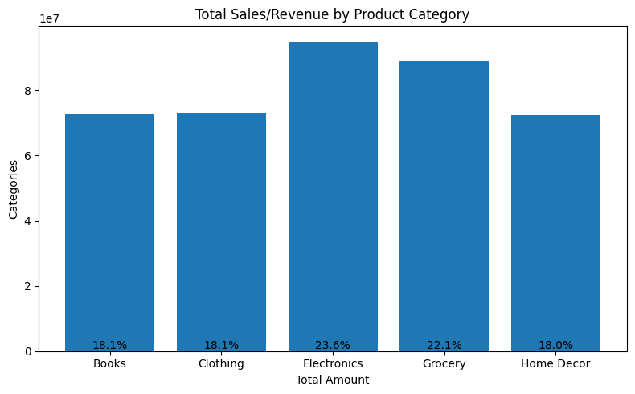

```python
# show the data in visulize in graph.
categories = product_ctg.index
values = product_ctg.values

total = sum(values)
percentages = [v / total * 100 for v in values]
plt.figure(figsize=(8, 5))
plt.xlabel('Total Amount')
plt.ylabel('Categories')
plt.title('Total Sales/Revenue by Product Category')

plt.bar(categories, values)

plt.tight_layout()

# for ax in g.axes.flat:
#     for container in ax.containers:
#         ax.bar_label(container, labels=[f'{bar.get_height():.1f}%' for bar in container])

for i, v in enumerate(percentages):
    plt.text(i, v, f"{v:.1f}%", ha='center',va='bottom')
# plt.savefig('Total Revenue By Product Category.png',dpi=300)
plt.show()
```

### Avobe The Graph Description

- The total sales analysis reveals that Electronics is the top-performing category, contributing 23.6% of the total revenue, indicating strong consumer demand and value in this segment.
- Grocery closely follows with 22.1%, reflecting consistent high-volume sales.
- Books and Clothing have nearly equal shares, each at 18.1%, showing moderate but stable demand.
- Home Decor holds the smallest share at 18.0%, which suggests room for growth in this category.
- Overall, Electronics and Grocery together account for nearly 46% of total revenue.  
  **Recommendation:**
- Focus on expanding Electronics and Grocery sales with targeted promotions.
- Boost marketing and product variety for Home Decor, Books, and Clothing to increase their revenue share.

## Total Revenue

```python
# total revenue.
total_revenue = df['Total_Amount'].sum()
print(f'Total Revenue : {total_revenue}')
```

```
Total Revenue : 401826431
```

### Total Revenue by Brand and Category

```python
# info about the product brand
df['Product_Brand'].value_counts()
```

```
Product_Brand
Pepsi                29537
Coca-Cola            17951
HarperCollins        17901
Zara                 17876
Samsung              17866
Sony                 17848
Adidas               17758
Bed Bath & Beyond    17746
Home Depot           17673
Random House         17671
Nike                 17646
Nestle               17637
Penguin Books        17627
Apple                17574
IKEA                 17520
Whirepool             7289
Mitsubhisi            6580
BlueStar              2208
Name: count, dtype: int64
```

```python
# check the Product Brands & Category Sales.
tot_rev_brand = df.groupby(['Product_Brand','Product_Category'])['Total_Amount'].sum().reset_index()
```

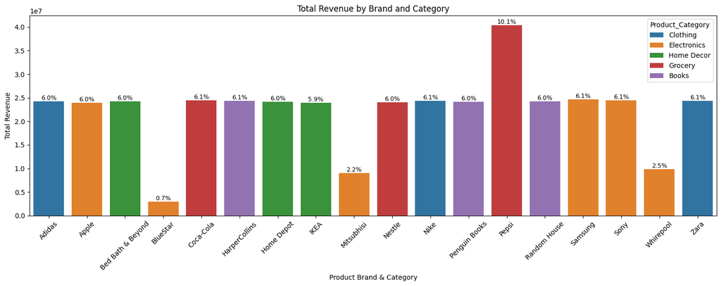

```python
# show the data in visulize in graph.

tot_rev_brand = df.groupby(['Product_Brand','Product_Category'])['Total_Amount'].sum().reset_index()

plt.figure(figsize=(15,6))

ax = sns.barplot(data=tot_rev_brand, x='Product_Brand', y='Total_Amount', hue='Product_Category')

for i in ax.containers:

    ax.bar_label(i, labels=[f"{(v.get_height() / total_revenue) * 100:.1f}%" for v in i], label_type='edge', fontsize=9)

plt.title('Total Revenue by Brand and Category')
plt.xlabel('Product Brand & Category')
plt.ylabel('Total Revenue')
plt.xticks(rotation=45)
plt.tight_layout()

# for ax in g.axes.flat:
#     for container in ax.containers:
#         ax.bar_label(container, labels=[f'{bar.get_height():.1f}%' for bar in container])
# plt.savefig('Total Revenue by Brand and Category.png',dpi=300)
plt.show()
```

### Avobe The Graph Description

- Pepsi (Grocery) makes the most, with 10.1% of the total revenue. Most other big brands as Adidas (Clothing), Apple (Electronics), Bed Bath & Beyond (Home Decor), Coca-Cola (Grocery), HarperCollins (Books), and Samsung (Electronics) each make about 6.0% to 6.1%, which means their performance is quite steady.
- Some brands are making much less — Bluestar (Electronics) has only 0.7%, Mitsubishi has 2.2%, and Whirlpool has 2.5%, which shows they are not doing well.
- The Electronics category has the biggest difference between high and low performers. In contrast, categories like Books, Clothing, and Home Decor have more even earnings.
- Overall, most brands are doing okay, but Pepsi is leading by a lot, and a few electronics brands need attention.  
  **Recommendation:**
- companies should focus on helping low-performing brands like Bluestar, Mitsubishi, and Whirlpool by improving marketing, product quality, or pricing.
- Strong brands like Pepsi can be used for promotions or to launch new products.
- the Electronics category shows mixed results, it's important to find out why some brands are doing well and others are not. At the same time, steady brands contributing around 6% should be supported to keep revenue stable.
- It reducing too much dependence on Pepsi will help balance the business and lower risk.

### Total Revenue by Product Type and Category

```python
# Clean/remove The Extra Space.
df.columns = df.columns.str.strip()
```

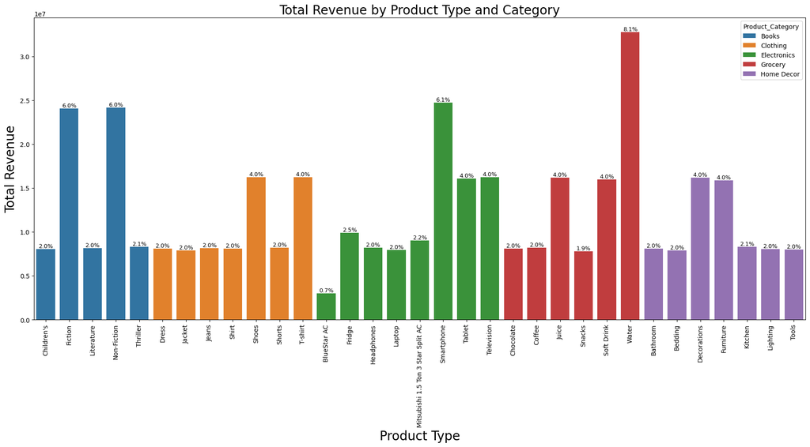

```python
# show the data in visulize in graph.

plt.figure(figsize=(18, 10))

tot_pdc_type = df.groupby(['Product_Category','Product_Type'])['Total_Amount'].sum().reset_index()

ax = sns.barplot(data=tot_pdc_type, x='Product_Type', y='Total_Amount',hue='Product_Category')

for i in ax.containers:

    ax.bar_label(i, labels=[f"{(v.get_height() / total_revenue) * 100:.1f}%" for v in i], label_type='edge', fontsize=9)

plt.title('Total Revenue by Product Type and Category',fontsize=20)
plt.xlabel('Product Type',fontsize=20)
plt.ylabel('Total Revenue',fontsize=20)
plt.xticks(rotation=90)

plt.tight_layout()
# for ax in g.axes.flat:
#     for container in ax.containers:
#         ax.bar_label(container, labels=[f'{bar.get_height():.1f}%' for bar in container])
# plt.savefig('Total Revenue by Product Type and Category.png',dpi=300)

plt.show()
```

### Second Problems

**We want to personalize marketing and improve ROI. To do this, we need to segment our customers based on age, gender, income, and customer segment — and understand who brings the highest sales.**

- Which customer segments (age, gender, income) contribute the most to sales?

#### Create a New Columns Age Group Based On Age

```python
def age_group(a):

    if a >= 12 and a <= 19:
        return'Teenager'
    elif a >= 20 and a <= 59:
        return 'Adult'
    elif a >= 60 and a <= 100:
       return 'Senior Citizen'

df['Age_Group'] = df['Age'].apply(age_group)
```

#### Age Group Based Total Sales

```python
# analysis the Age_Group based sales.

df.groupby('Age_Group')['Total_Amount'].sum()
```

```
Age_Group
Adult             340228758
Senior Citizen     38718619
Teenager           22879054
Name: Total_Amount, dtype: int64
```

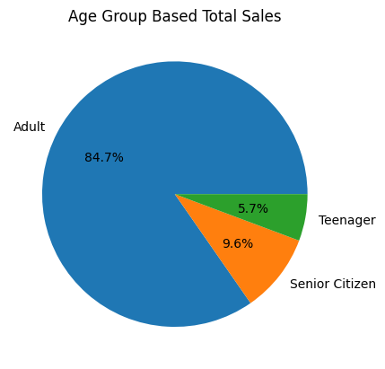

```python
# analysis in graph.
Age_Group = df.groupby('Age_Group')['Total_Amount'].sum()
age_ctg = Age_Group.index
values = Age_Group.values
plt.pie(Age_Group,autopct='%1.1f%%',labels=age_ctg)
plt.title('Age Group Based Total Sales')
# for ax in g.axes.flat:
#     for container in ax.containers:
#         ax.bar_label(container, labels=[f'{bar.get_height():.1f}%' for bar in container])
# plt.savefig('Age Group Based Total Sales.png',dpi=300)
plt.show()
```

### Above The Graph Description

- The chart shows that Adults dominate total sales, contributing 84.7%, making them the main target group. Senior Citizens account for 9.6%, while Teenagers make up just 5.7% of sales. This suggests that most purchasing activity comes from adults.
- Sales from teenagers and seniors are much lower, indicating potential areas to grow through targeted products or promotions designed specifically for these age groups.  
  **Recommendation:**
- The Adult Age Group Target the most sales.
- The Teenager and Senior Citizen to target Participate more sales using notification, marketing, discount.

#### Gender Based Total Sales

```python
# analysis in numbers.
df.groupby('Gender')['Total_Amount'].sum()
```

```
Gender
Female    152029946
Male      249796485
Name: Total_Amount, dtype: int64
```

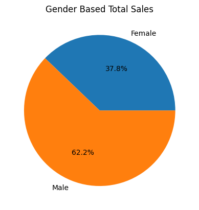

```python
# analysis in graph
Age_Gender = df.groupby('Gender')['Total_Amount'].sum()
categories = Age_Gender.index
plt.pie(Age_Gender,labels=categories,autopct='%1.1f%%')
plt.title('Gender Based Total Sales')
# plt.savefig('Gender Based Total Sales.png',dpi=300)

plt.show()
```

### Avobe THe Graph Description

- The chart indicates that males account for 62.2% of total sales, while females contribute 37.8%. This suggests that male customers are currently the dominant buyers.
- The noticeable gap implies a potential opportunity to increase sales from female customers by tailoring product offerings, marketing strategies, or promotions to better suit their preferences and shopping behaviours.  
  **Recommendation:**
- The Male to target more sales than marketing and offers.
- The Female to target contribute more sales ads, marketing and offers or discount.

#### Age Group And Gender Based Sales Total Sales

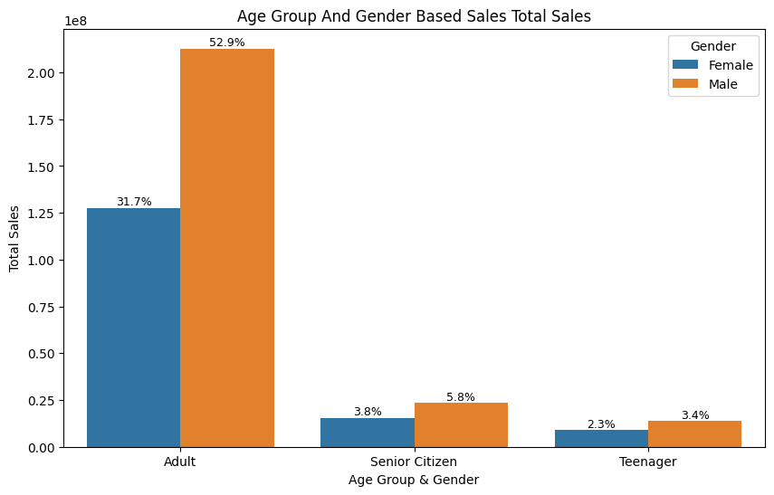

```python
# both columns Age_Group and Gender.

age_gender = df.groupby(['Age_Group','Gender'])['Total_Amount'].sum().reset_index()
labels = age_gender.index
plt.figure(figsize=(10,6))
ax = sns.barplot(data=age_gender,x='Age_Group',y='Total_Amount',hue='Gender')
plt.title('Age Group And Gender Based Sales Total Sales')
plt.xlabel('Age Group & Gender')
plt.ylabel('Total Sales')

for i in ax.containers:
    # ax.bar_label(i, fmt='%1.1f', label_type='edge') # see the only values in numbers format.
    ax.bar_label(i, labels=[f"{(v.get_height() / total_revenue) * 100:.1f}%" for v in i], label_type='edge', fontsize=9)
# for ax in g.axes.flat:
#     for container in ax.containers:
#         ax.bar_label(container, labels=[f'{bar.get_height():.1f}%' for bar in container])
# plt.savefig('Age Group And Gender Based Total Sales.png',dpi=300)
plt.show()
```

### Above The Graph Desvription

- The chart shows that adult males dominate sales with a significant 52.9% share, followed by adult females at 31.7%. Senior citizens and teenagers contribute comparatively less, with male senior citizens at 5.8% and female senior citizens at 3.8%, while teenage males and females contribute 3.4% and 2.3% respectively.
- This clearly indicates that the adult age group, especially males, are the primary buyers.  
  **Recommendation:**
- Adult Males – They are the top buyers, focus campaigns and premium products on this group.
- Adult Females More Second highest group, increase sales with female-focused marketing.
- The Teenager and Senior Citizen is low sales they do the try this age group marketing and promotion to growth together.

### Gender And Income Brackets Based Total Sales

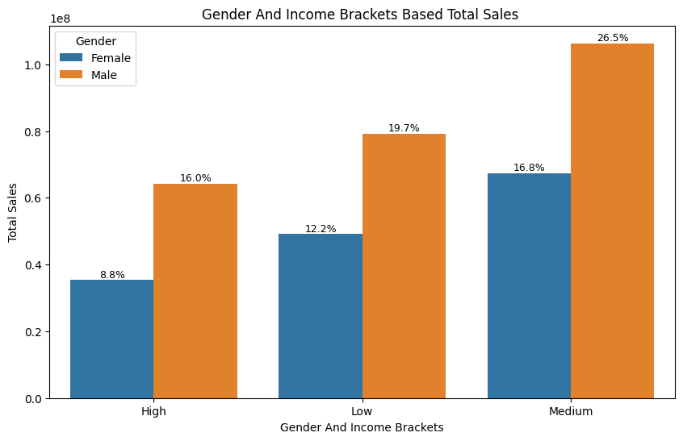

```python
# income based Sales Contribute


age_gender = df.groupby(['Income','Gender'])['Total_Amount'].sum().reset_index()
labels = age_gender.index
plt.figure(figsize=(10,6))
ax = sns.barplot(data=age_gender,x='Income',y='Total_Amount',hue='Gender')
plt.title('Gender And Income Brackets Based Total Sales ')
plt.xlabel('Gender And Income Brackets')
plt.ylabel('Total Sales')

for i in ax.containers:
    # ax.bar_label(i, fmt='%1.1f', label_type='edge') # see the only values in numbers format.
    ax.bar_label(i, labels=[f"{(v.get_height() / total_revenue) * 100:.1f}%" for v in i], label_type='edge', fontsize=9)
# for ax in g.axes.flat:
#     for container in ax.containers:
#         ax.bar_label(container, labels=[f'{bar.get_height():.1f}%' for bar in container])
# plt.savefig('Gender And Income Brackets Based Total Sales.png',dpi=300)
plt.show()
```

### Avobe The Graph Description

- Men spent more than women in all income levels.
- The highest spending came from men in the medium-income group 26.5%, followed by women in the same group 16.8%. In the low-income group, men spent 19.7%, while women spent 12.2%. The least spending came from the high-income group, where men spent 16% and women only 8.8%. This means that medium-income men are the biggest buyers, and there’s a chance to increase sales by encouraging more spending from women.  
  **Recommendation:**
- Focus on Medium Males Because They are the highest spenders and key revenue drivers.
- Female spending is lower, targeted offers or promotions can help increase it.

### Gender And Customer Segment Based Total Sales

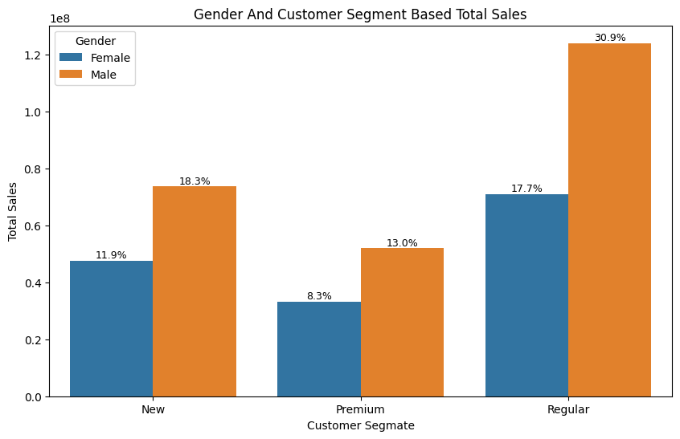

```python
customer_sgm = df.groupby(['Customer_Segment','Gender'])['Total_Amount'].sum().reset_index()
x = customer_sgm.index
y = customer_sgm.values
plt.figure(figsize=(10,6))
ax = sns.barplot(data=customer_sgm,x='Customer_Segment',y='Total_Amount',hue='Gender')
# plt.bar(x,y)
plt.subplot()
plt.title('Gender And Customer Segment Based Total Sales')
plt.xlabel('Customer Segmate')
plt.ylabel('Total Sales')


for i in ax.containers:
    ax.bar_label(i, labels=[f"{(v.get_height() / total_revenue)* 100:.1f}%" for v in i], label_type='edge', fontsize=9)

# for ax in g.axes.flat:
#     for container in ax.containers:
#         ax.bar_label(container, labels=[f'{bar.get_height():.1f}%' for bar in container])
# plt.savefig('Gender And Customer Segment Based Total Sales.png',dpi=300)

plt.show()
```

### Above The Chart Description

- The Male customers contribute more sales than Female customers across all segments.
- The Regular Male segment leads with the highest contribution at 30.9%, followed by Regular Female at 17.7%, making the Regular segment the most profitable overall. In the New segment, Males account for 18.3% while Females contribute 11.9%.
- The Premium segment has the lowest share overall, with Males at 13.0% and Females at 8.3%.  
  **Recommendation:**
- Focus marketing and loyalty efforts on Regular and New Male segments.
- Use personalized campaigns to engage Premium and Female customers.
- Explore ways to increase value and benefits in the Premium segment.

### Income Brackets And Customer Segment Based Total Sales

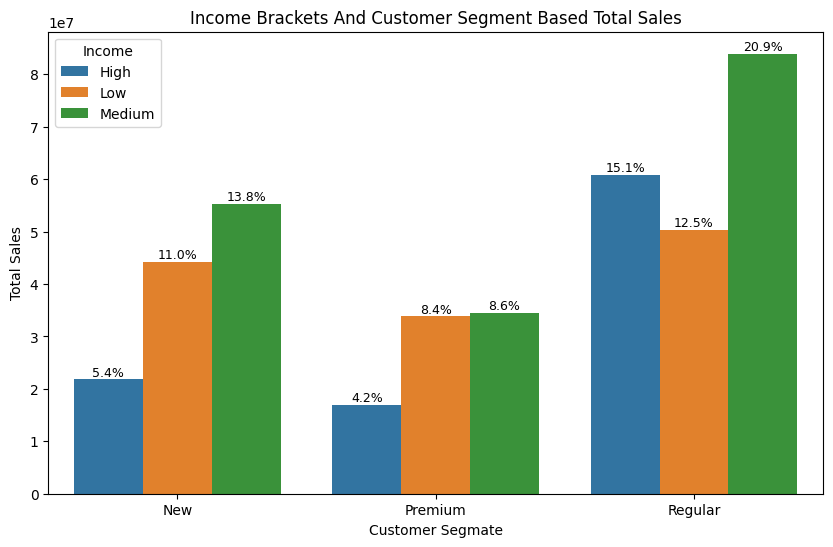

```python
# same chart but with income Brackets.

customer_sgm = df.groupby(['Customer_Segment','Income'])['Total_Amount'].sum().reset_index()
x = customer_sgm.index
y = customer_sgm.values
plt.figure(figsize=(10,6))
ax = sns.barplot(data=customer_sgm,x='Customer_Segment',y='Total_Amount',hue='Income')
# plt.bar(x,y)
plt.subplot()
plt.title('Income Brackets And Customer Segment Based Total Sales')
plt.xlabel('Customer Segmate')
plt.ylabel('Total Sales')


for i in ax.containers:
    ax.bar_label(i, labels=[f"{(v.get_height() / total_revenue)* 100:.1f}%" for v in i], label_type='edge', fontsize=9)

# for ax in g.axes.flat:
#     for container in ax.containers:
#         ax.bar_label(container, labels=[f'{bar.get_height():.1f}%' for bar in container])
# plt.savefig('Income Brackets And Customer Segment Based Total Sales.png',dpi=300)
plt.show()
```

### Avobe The Chart Description

- The Medium income contribute the highest overall sales across all segments.
- In the Regular customer segment, Medium income users lead with 20.9%, followed by High income at 15.1%, and Low income at 12.5%. The New segment also shows strong sales from Medium income 13.8% and Low income 11.0% customers, while High income contributes just 5.4%.
- In the Premium segment, sales are almost and Medium income customers 8.6%, and Low income at 8.4% with High income contributing the least at 4.2%.  
  **Recommendation:**
- The Regular Segment Customer Medium Income Brackets more sales offers and Low Income Brackets participate offers and discount or High Income
- Brackets more sales do ads and marketing.
- The Second high sales contribute is New Segment they Medium , Low and High Income engagement to more sales.
- The Premium Segment all Income Brackets do the special offers and discount marketing.

## Third Problems

**As we plan to expand operations, leadership wants insights into regional performance. We need to know which countries, states, and cities generate the most revenue and which areas need attention.**

- Which countries, states, or cities have the highest total sales?

### Top 10 Cities Based Total Sales

```python
# total/count of the city.
city = df['City'].value_counts()
count=0
for i in enumerate(city):
    count = count +1


print(f'Total City is : {count}')
```

```
Total City is : 130
```

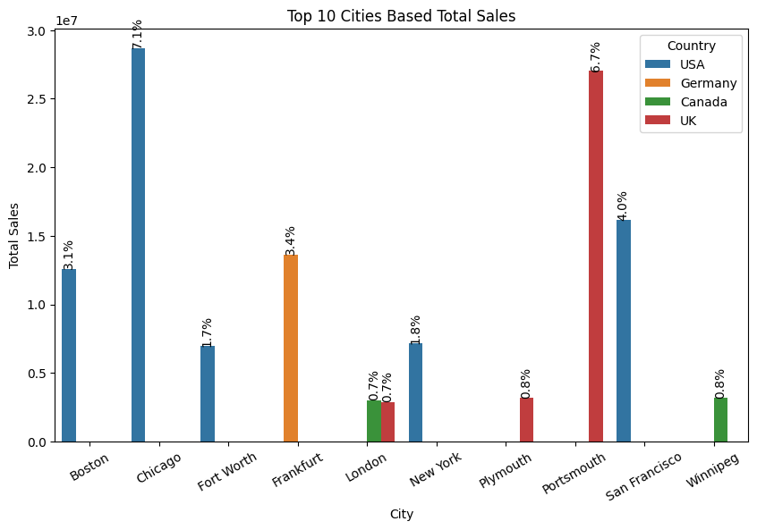

```python
# top 10 citys highest revenue.
top_10_city = df.groupby('City')['Total_Amount'].sum().nlargest(10).index
top_df = df[df['City'].isin(top_10_city)]

tot_city_rvn = top_df.groupby(['City','Country'])['Total_Amount'].sum().reset_index()
plt.subplots(figsize=(10, 6))

ax = sns.barplot(data=tot_city_rvn , x='City',y='Total_Amount',hue='Country')
plt.title('Top 10 Cities Based Total Sales')
plt.xticks(rotation=30)
plt.xlabel('City')
plt.ylabel('Total Sales')

for i in ax.containers:
    ax.bar_label(i,labels = [f"{(v.get_height() / total_revenue)* 100:.1f}%" for v in i] , label_type='edge',fontsize=10,rotation=90)


# for ax in g.axes.flat:
#     for container in ax.containers:
#         ax.bar_label(container, labels=[f'{bar.get_height():.1f}%' for bar in container])
# plt.savefig('Top 10 Cities Based Total Sales.png',dpi=300)

plt.show()
```

#### Avobe The Chart Description

- Highest Sales City is First Chicago 7.1% Country is USA and second is Portsmouth 6.7 Country is UK.
- The Middle level Sales contribute city is San Francisco USA with 4.0%. Frankfurt Germany adds 3.4%, and Boston USA adds 3.1%.
- The Low level Sales Contribute city is New York USA with 1.8% and Fort Worth USA add 1.7% or London UK with 0.7% and Canada with 0.7 %, Plymouth UK add 0.8%, Winnipeg Canada with 0.8%.
- Most of the top cities are in the USA, showing strongest market and Other Cities in the UK, Canada, and Germany have smaller sales.  
  **Recommendation:**
- Invest more in the USA, especially in high-performing cities like Chicago and San Francisco.
- Explore growth opportunities in underperforming cities like London Canada and Plymouth UK.
- The lowest sales cities engage more sales using offers, ads.

### Last Top 10 Cities by Total Sales

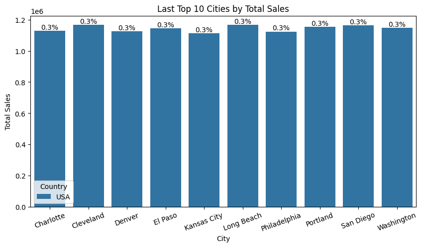

```python
# top 10 citys lowest revenue.
top_10_city = df.groupby('City')['Total_Amount'].sum().nsmallest(10).index
top_df = df[df['City'].isin(top_10_city)]

tot_city_rvn = top_df.groupby(['City','Country'])['Total_Amount'].sum().reset_index()
plt.subplots(figsize=(10, 5))

ax = sns.barplot(data=tot_city_rvn , x='City',y='Total_Amount',hue='Country')
plt.title('Last Top 10 Cities by Total Sales')
plt.xticks(rotation=20)
plt.xlabel('City')
plt.ylabel('Total Sales')

for i in ax.containers:
    ax.bar_label(i,labels = [f"{(v.get_height() / total_revenue)* 100:.1f}%" for v in i] , label_type='edge',fontsize=10)

# for ax in g.axes.flat:
#     for container in ax.containers:
#         ax.bar_label(container, labels=[f'{bar.get_height():.1f}%' for bar in container])
# plt.savefig('Last Top 10 Cities by Total Sales.png',dpi=300)
plt.show()
```

#### Avobe The Chart Description

- In all the USA Each city, including Charlotte, Cleveland, Denver, El Paso, Kansas City, Long Beach, Philadelphia, Portland, San Diego, and Washington, contributes just 0.3% of the total Sales.
- The revenue levels are very similar across these cities. Suggesting they are underperforming or less focused markets.  
  **Recommendation:**
- Run targeted campaigns Use promotions or local advertising to increase visibility in these cities.
- Improve product and service access Check if distribution or service issues are limiting reach.

### Top 10 State Based Total Sales

```python
# count the state
state_ctn = df['State'].value_counts()
count=0
for i in enumerate(state_ctn):
    count = count + 1

print(f'Total State is : {count}')
```

```
Total State is : 54
```

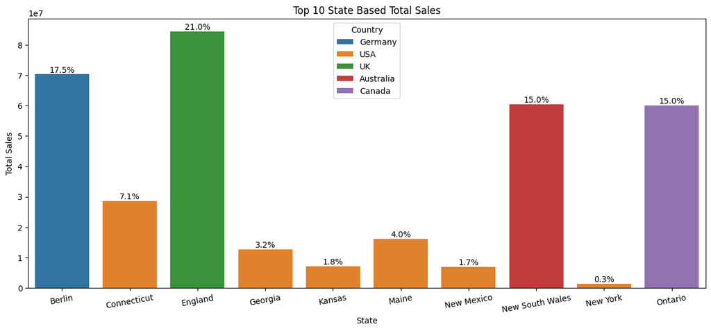

```python
top_state = df.groupby('State')['Total_Amount'].sum().nlargest(10).index

store_sts_val = df[df['State'].isin(top_state)]


tot_sts_rvn = store_sts_val.groupby(['State','Country'])['Total_Amount'].sum().reset_index()

plt.subplots(figsize=(15, 6))
ax = sns.barplot(data=tot_sts_rvn , x='State',y='Total_Amount',hue='Country')
plt.xticks(rotation=10)
plt.title('Top 10 State Based Total Sales')
plt.xlabel('State')
plt.ylabel('Total Sales')

for i in ax.containers:
    ax.bar_label(i, labels = [f"{(v.get_height() / total_revenue )* 100:.1f}%" for v in i], label_type='edge',fontsize=10 )

# for ax in g.axes.flat:
#     for container in ax.containers:
#         ax.bar_label(container, labels=[f'{bar.get_height():.1f}%' for bar in container])
# plt.savefig('Top 10 State Based Total Sales.png',dpi=300)

plt.show()
```

### Avobe The Chart Description

- The England, Berlin, these states contribute with 21.0%, 17.5% and New South Wales, and Ontario, as these states contribute 15.0% These high-performing regions indicate strong market potential.
- On the other hand, New York is 0.3% and New Mexico is 1.7% or Kansas is 1.8% show very low revenue contribution.
- The Mid-level Sales contribute state is Georgia is 3.2% and Maine is 4.0%.  
  **Recommendation:**
- Focus on the high Sales states England, Berlin, Ontario, and New South Wales to boost returns.
- Improve marketing or service in low-performing areas New York and New Mexico, Georgia, Maine.
- Explore why top cities Chicago and Portsmouth are performing well, and apply similar strategies elsewhere in this city.
- Consider reducing investment in cities consistently showing low revenue.

### Country Based Total Sales

```python
# check total country.
tot_cty = df['Country'].value_counts()
count = 0
# for i in tot_cty:
#     count = count +1

# print(f'Total Country is : {count}')
tot_cty
```

```
Country
USA          92800
UK           61397
Germany      51432
Australia    44170
Canada       44109
Name: count, dtype: int64
```

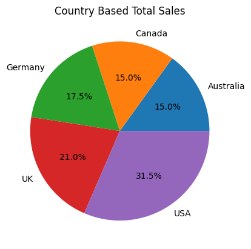

```python
tot_cty_rvn = df.groupby('Country')['Total_Amount'].sum()
country_name = tot_cty_rvn.index
# value = tot_cty_rvn.values
plt.pie(tot_cty_rvn,autopct='%1.1f%%',labels=country_name)
plt.title('Country Based Total Sales')
# for ax in g.axes.flat:
#     for container in ax.containers:
#         ax.bar_label(container, labels=[f'{bar.get_height():.1f}%' for bar in container])
# plt.savefig('Country Based Total Sales.png',dpi=300)
plt.show()
```

#### Avobe the Chart Description

- The USA country contributes the highest share of total sales with 31.5. UK is 21.0%, also showing strong performance.
- Germany holds 17.5%, a moderate but notable Sales. Canada and Australia both contribute 15.0%, showing balanced but comparatively lower performance.  
  **Recommendation:**
- Focus the USA Country Because They Highest Sales.
- The UK and GERMANY strong markets that can be expanded with targeted strategies and more sales.
- The Canada and Australia run marketing or promotional campaigns to increase market Sales.

### Fourth Problems

**The marketing team wants to schedule campaigns more effectively. We need a clear understanding of how sales behave over time — by month and year — to identify peak seasons and low-performing periods.**

- Which months or years show peak sales activity?

### Month & Year Based Total Sales

```python
mth_ctn = df['Month'].value_counts()
count = 0
for i in mth_ctn:
    count = count + 1

print(f'Total Month is : {count}')
```

```
Total Month is : 12
```

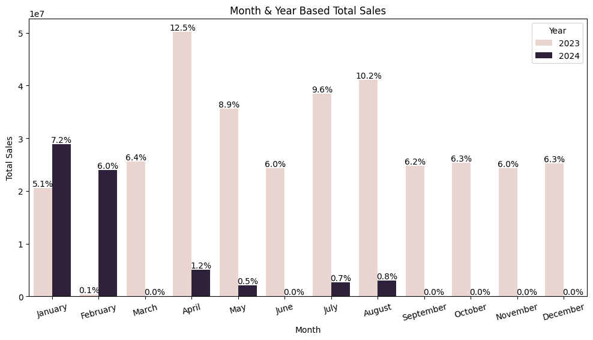

```python
mth_tot_sls = df.groupby(['Month','Year'])['Total_Amount'].sum().reset_index()

plt.figure(figsize=(12, 6))

month_order = ['January', 'February', 'March', 'April', 'May', 'June',
               'July', 'August', 'September', 'October', 'November', 'December']


ax = sns.barplot(data=mth_tot_sls , x='Month',y='Total_Amount',hue='Year',order=month_order)
plt.title('Month & Year Based Total Sales')
plt.xlabel('Month')
plt.ylabel('Total Sales')
plt.xticks(rotation=15)


for i in ax.containers:
    ax.bar_label(i,labels = [f'{(v.get_height() / total_revenue)* 100:.1f}%' for v in i], label_type='edge',fontsize=10)

# for ax in g.axes.flat:
#     for container in ax.containers:
#         ax.bar_label(container, labels=[f'{bar.get_height():.1f}%' for bar in container])
# plt.savefig('Month & Year Based Total Sales.png',dpi=300)
plt.show()
```

### Year Based Total Sales

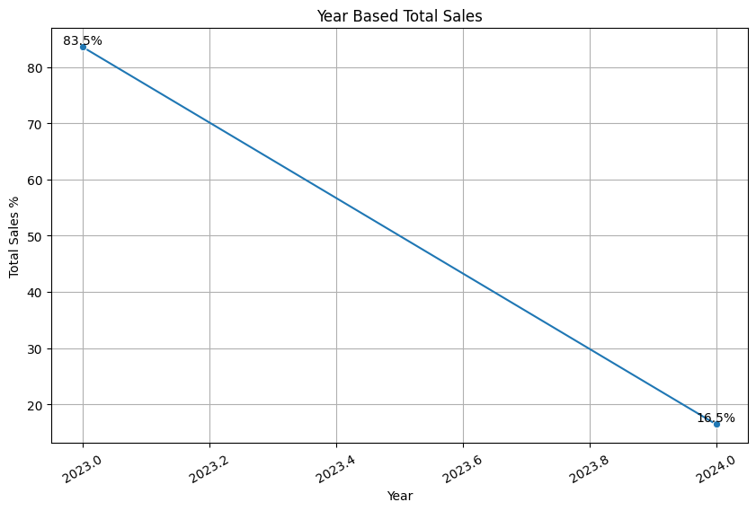

```python
year_tot_sls = df.groupby('Year')['Total_Amount'].sum().reset_index()
year_tot_sls['Percentage'] = (year_tot_sls['Total_Amount'] / total) * 100

plt.figure(figsize=(10, 6))

ax = sns.lineplot(data=year_tot_sls , x='Year',y='Percentage', marker='o')
plt.title('Year Based Total Sales')
plt.xlabel('Year')
plt.ylabel('Total Sales %')
plt.xticks(rotation=30)
plt.grid(True)

for i, row in year_tot_sls.iterrows():
    plt.text(row['Year'], row['Percentage'] + 0.5, f"{row['Percentage']:.1f}%", ha='center')


# for ax in g.axes.flat:
#     for container in ax.containers:
#         ax.bar_label(container, labels=[f'{bar.get_height():.1f}%' for bar in container])
# plt.savefig('Year Based Total Sales.png',dpi=300)

plt.show()
```

#### Above The Chart Description

- There is a major different in total sales from 2023, 83.5% to 2024, 16.5%.
- In 2024 incomplete data for the year. **Recommendation:**
- Implement corrective campaigns in upcoming months.

```python
# show the only name of the year 2024.
# y = df[df['Year']==2024]
# print(y['Month'].unique())
```

### Fifth Problem

**Some products sell well but receive poor ratings. This may harm long-term customer trust. We want to cross-analyze sales volume with customer ratings to identify risky or high-potential products.**

- Which products or brands are high-selling but poorly rated?
- Identify high-selling but low-rated products.
- Flag low-selling but high-rated products for potential promotion.
- Suggest actions for improving product quality or visibility.

### Product Category And Rating Based Sales

```python
# info about the Rayings values.
df['Ratings'].value_counts()
```

```
Ratings
4.0    95459
2.0    61018
5.0    48811
3.0    46442
1.0    42178
Name: count, dtype: int64
```

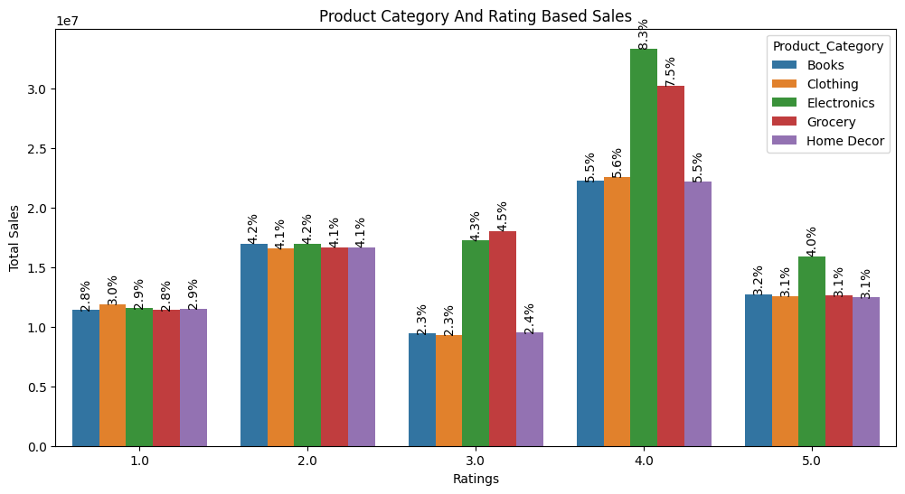

```python
rtg_pdc_sls = df.groupby(['Ratings','Product_Category'])['Total_Amount'].sum().reset_index()

plt.figure(figsize=(12,6))
ax = sns.barplot(data=rtg_pdc_sls,x='Ratings',y='Total_Amount',hue='Product_Category')
plt.title('Product Category And Rating Based Sales')
plt.xlabel('Ratings')
plt.ylabel('Total Sales')

for i in ax.containers:
    ax.bar_label(i,labels = [f"{(v.get_height() / total_revenue)* 100:.1f}%" for v in i],label_type='edge',fontsize=10,rotation=90)

# for ax in g.axes.flat:
#     for container in ax.containers:
#         ax.bar_label(container, labels=[f'{bar.get_height():.1f}%' for bar in container])
plt.savefig('Product Category And Rating Based Sales.png',dpi=300)

plt.show()
```

### Product Brand and Rating Or Country Based Sales

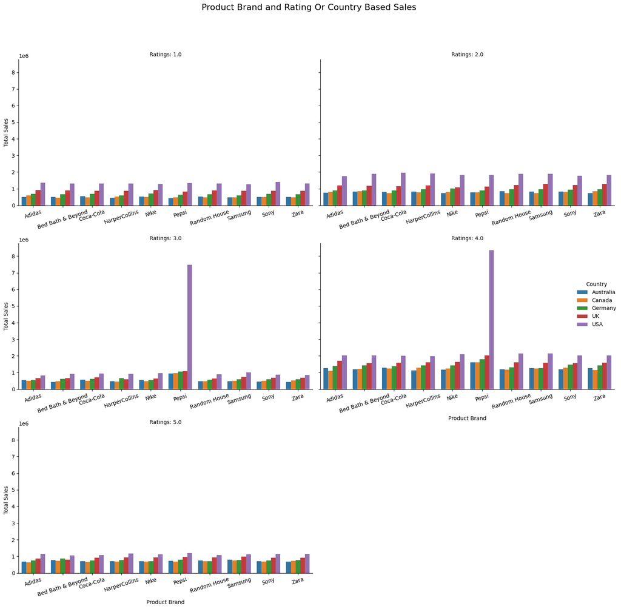

```python
top_10_pdc = df.groupby('Product_Brand')['Total_Amount'].sum().nlargest(10).index

store_10_pdc = df[df['Product_Brand'].isin(top_10_pdc)]

rtg_pdc_sls = store_10_pdc.groupby(['Product_Brand','Country','Ratings'])['Total_Amount'].sum().reset_index()
plt.figure(figsize=(15,6))
# Use catplot to create faceted bar charts
g = sns.catplot(
    data=rtg_pdc_sls,
    x='Product_Brand',
    y='Total_Amount',
    hue='Country',
    col='Ratings',
    kind='bar',
    height=5,
    aspect=1.5,
    col_wrap=2
)

for ax in g.axes.flat:
    # Rotate labels using the underlying matplotlib Text objects
    for label in ax.get_xticklabels():
                 label.set_rotation(90)
    ax.xaxis.set_tick_params(labelbottom=True)

for ax in g.axes.flat:
    ax.tick_params(axis='x', rotation=17.5)



g.set_axis_labels("Product Brand", "Total Sales")
g.set_titles("Ratings: {col_name}")
g.fig.suptitle("Product Brand and Rating Or Country Based Sales", fontsize=16, y=1.05)


# for ax in g.axes.flat:
#     for container in ax.containers:
#         ax.bar_label(container, labels=[f'{bar.get_height():.1f}%' for bar in container])
# plt.savefig('Product Brand and Rating Or Country Based Sales.png',dpi=300)

plt.tight_layout()
plt.show()
```

#### Product Category and Rating Or Country Based Sales

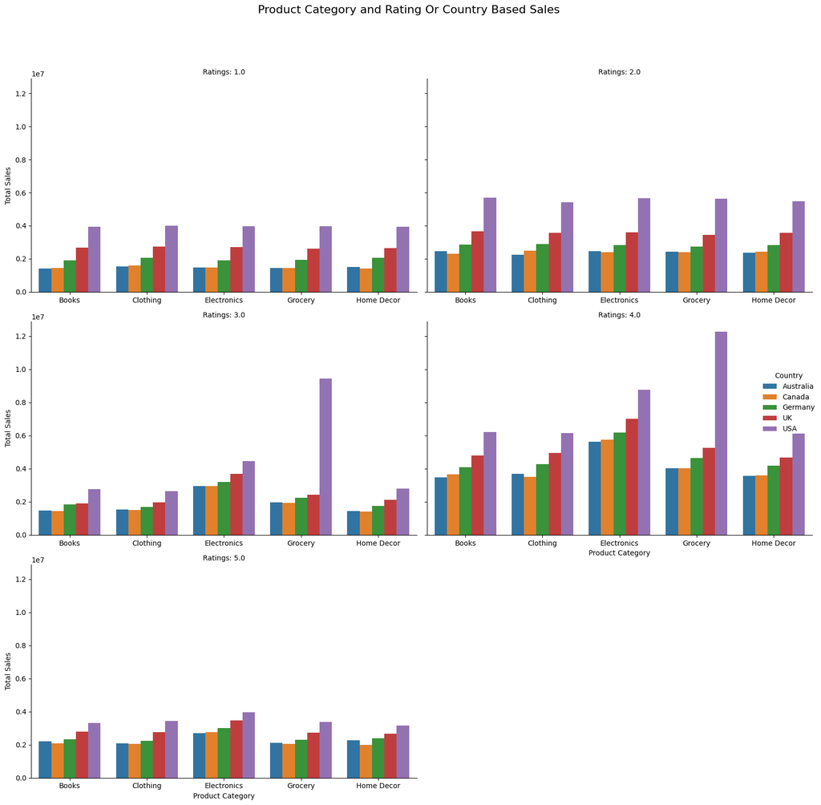

```python
top_10_pdc = df.groupby('Product_Category')['Total_Amount'].sum().nlargest(10).index

store_10_pdc = df[df['Product_Category'].isin(top_10_pdc)]

rtg_pdc_sls = store_10_pdc.groupby(['Product_Category','Country','Ratings'])['Total_Amount'].sum().reset_index()

plt.figure(figsize=(12,6))
# Use catplot to create faceted bar charts
g = sns.catplot(
    data=rtg_pdc_sls,
    x='Product_Category',
    y='Total_Amount',
    hue='Country',
    col='Ratings',
    kind='bar',
    height=5,
    aspect=1.5,
    col_wrap=2
)

for ax in g.axes.flat:
    # Rotate labels using the underlying matplotlib Text objects
    # for label in ax.get_xticklabels():
        # label.set_rotation(45)
    ax.xaxis.set_tick_params(labelbottom=True)





g.set_axis_labels("Product Category", "Total Sales")
g.set_titles("Ratings: {col_name}")
g.fig.suptitle("Product Category and Rating Or Country Based Sales", fontsize=16, y=1.05)

# plt.savefig('Product Category and Rating Or Country Based Sales.png',dpi=300)
plt.tight_layout()
```

## Six Problems

**Customer feedback has highlighted concerns about delivery speed and reliability. We need to analyze how different shipping methods affect order status and customer satisfaction.**

- Compare order outcomes by shipping method.
- Analyze feedback and ratings by shipping type.
- Recommend the most reliable and preferred delivery options.

### Order Status by Shipping Method

```python
# info about the Order_Status.
df['Order_Status'].value_counts()
```

```
Order_Status
Delivered     127238
Shipped        63275
Processing     55654
Pending        47741
Name: count, dtype: int64
```

```python
# info about the Shipping method.

df['Shipping_Method'].value_counts()
```

```
Shipping_Method
Same-Day    101540
Express      99599
Standard     92769
Name: count, dtype: int64
```

```python
# info about the Feedback.
df['Feedback'].value_counts()
```

```
Feedback
Excellent    98016
Good         92696
Average      61018
Bad          42178
Name: count, dtype: int64
```

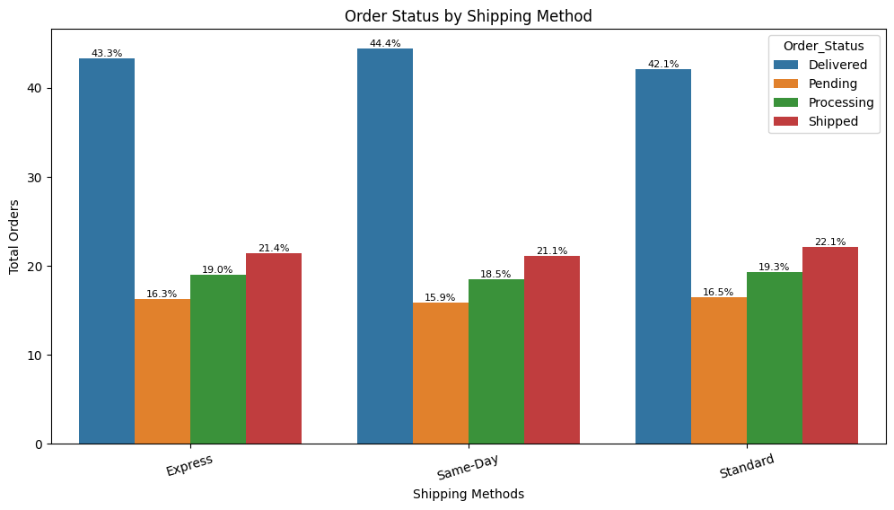

```python
odr_diff_ship = df.groupby(['Shipping_Method','Order_Status']).size().reset_index(name='Count')
total_per_shipping = odr_diff_ship.groupby('Shipping_Method')['Count'].transform('sum')
odr_diff_ship['Percentage'] = (odr_diff_ship['Count']/ total_per_shipping * 100).round(1)

plt.figure(figsize=(12, 6))
ax = sns.barplot(data=odr_diff_ship,x='Shipping_Method', y='Percentage',hue='Order_Status')
plt.title("Order Status by Shipping Method")
plt.xlabel('Shipping Methods')
plt.ylabel('Total Orders')
plt.xticks(rotation=17)
# plt.legend(bbox_to_anchor=(1.05, 1.2),loc='upper center')
for i in ax.containers:
    ax.bar_label(i, fmt='%.1f%%', label_type='edge', fontsize=8)

# plt.savefig('Order Status by Shipping Method.png',dpi=300)
plt.show()
```

### Feedback and Shipping Method by Orders

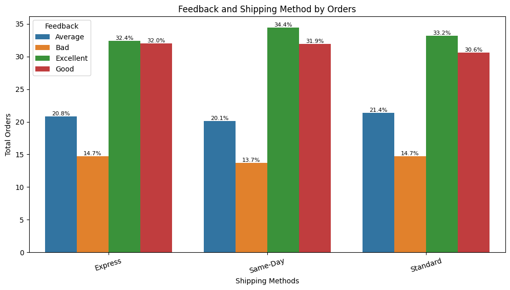

```python
odr_diff_ship = df.groupby(['Shipping_Method','Feedback']).size().reset_index(name='Count')
total_per_shipping = odr_diff_ship.groupby('Shipping_Method')['Count'].transform('sum')
odr_diff_ship['Percentage'] = (odr_diff_ship['Count']/ total_per_shipping * 100).round(1)

plt.figure(figsize=(12, 6))
ax = sns.barplot(data=odr_diff_ship,x='Shipping_Method', y='Percentage',hue='Feedback')
plt.title("Feedback and Shipping Method by Orders")
plt.xlabel('Shipping Methods')
plt.ylabel('Total Orders')
plt.xticks(rotation=17)
# plt.legend(bbox_to_anchor=(1.05, 1.2),loc='upper center')
for i in ax.containers:
    ax.bar_label(i, fmt='%.1f%%', label_type='edge', fontsize=8)

plt.savefig('Feedback and Shipping Method by Orders.png',dpi=300)
plt.show()
```

### Seven Problems

**We want to reduce cart abandonment and improve checkout flow. To do this, we need to identify the most preferred payment methods across different customer groups and regions.**

- Which payment methods are used most often and by whom?
- Analyze usage of each payment method.
- Find trends by country, age, gender, and income.
- Recommend which payment options to highlight or add/remove.

### Most Use PayMent Method.

```python
df['Payment_Method'].value_counts()
```

```
Payment_Method
Credit Card    87780
Debit Card     74744
Cash           71925
PayPal         59459
Name: count, dtype: int64
```

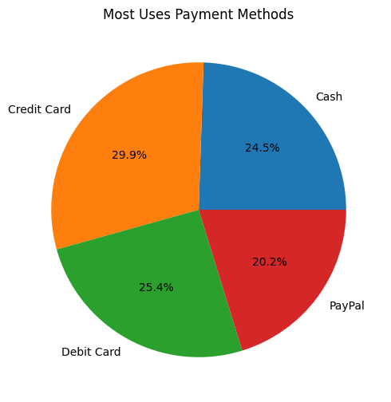

```python
most_use_pay = df.groupby('Payment_Method').size()
name = most_use_pay.index
plt.figure(figsize=(7,6))
plt.pie(most_use_pay,labels=name,autopct='%1.1f%%')
plt.title('Most Uses Payment Methods')
# plt.savefig('Most Uses Payment Methods.png',dpi=300)
plt.show()
```

### Above The Chart Description

- The most preferred payment method is Credit Card 29.9%, followed by Debit Card 25.4% and Cash 24.5%, while PayPal 20.2% is the least used.  
  **Recommendation:**
- digital transactions are more dominant than cash or online wallets.
- The give’s discounts and offers for PayPal and Cash users to boost adoption customers.
- The priority payment card options Credit and Debit on checkout for a smoother user experience.

### Age Group Based Uses Payment Methods

[figure not shown]

```python
age_wise_pay = df.groupby(['Payment_Method','Age_Group']).size().reset_index(name='count')
tot_payment = age_wise_pay.groupby('Payment_Method')['count'].transform('sum')
age_wise_pay['Percentage'] = (age_wise_pay['count'] / tot_payment * 100).round(1)

plt.figure(figsize=(10,6))
ax = sns.barplot(data=age_wise_pay,x='Age_Group',y='Percentage',hue='Payment_Method')
plt.title('Age Group Based Uses Payment Methods')
plt.xlabel('Age Group')
plt.ylabel('Total Percentage')
for i in ax.containers:
    ax.bar_label(i,fmt='%1.1f%%',label_type='edge',fontsize=10,rotation=45)

# plt.savefig('Age Group Based Uses Payment Methods.png',dpi=300)
plt.show()
```

#### Above The Chart Description

- Adults are the most uses users of all payment methods is PayPal 86.0%, Cash 84.4%, Debit Card 83.8%, Credit Card 82.9%.
- Senior Citizens show most payment usage is Highest with Credit Card 11.2% and 9.7%, Cash 9.2%, and Lowest with PayPal 7.0%.
- Teenagers have the least usage all payment methods around 6%–7% for all payment, with PayPal 7.0% slightly higher.  
  **Recommendation:**
- Focus marketing and loyalty programs on adults.
- Consider teen-focused offers discounts via prepaid cards and senior-friendly payment tutorials to broaden user base.

### Gender Based Uses Payment methods

[figure not shown]

```python
gen_tot_pay = df.groupby(['Payment_Method','Gender']).size().reset_index(name='count')
tot_payment = gen_tot_pay.groupby('Payment_Method')['count'].transform('sum')
gen_tot_pay['Percentage'] = (gen_tot_pay['count'] / tot_payment * 100).round(1)
plt.figure(figsize=(10,6))
# name = gen_tot_pay.index
ax = sns.barplot(data=gen_tot_pay,x='Payment_Method',y='Percentage',hue='Gender')
plt.title('Gender Based Uses Payment methods')
plt.xlabel('Payment Methods')
plt.ylabel('Total Percentage')
plt.legend(bbox_to_anchor=(0.8,0.7))
for i in ax.containers:
    ax.bar_label(i,fmt='%1.1f%%',label_type='edge',fontsize=10)

# plt.savefig('Gender Based Uses Payment methods.png',dpi=300)
plt.show()
```

#### Above The Chart Description

- Males consistently use all payment methods more than females.
- Male usage payment methods are ranges from 61.8% to 62.6% across methods.
- Females have lower usage across all payment types, the uses Between 37.4% and 38.2%.  
  **Recommendation:**
- Run promotions or discounts for females using specific payment methods.
- Collaborate with female-centric brands, influencers, or platforms.
- Highlight security features of each method.
- Create a feedback ask female users what would make them feel more confident and comfortable.